# PlotMicrobiome analysis with AI report

### Barplot of taxonomic composition

### Barplot at phylum level

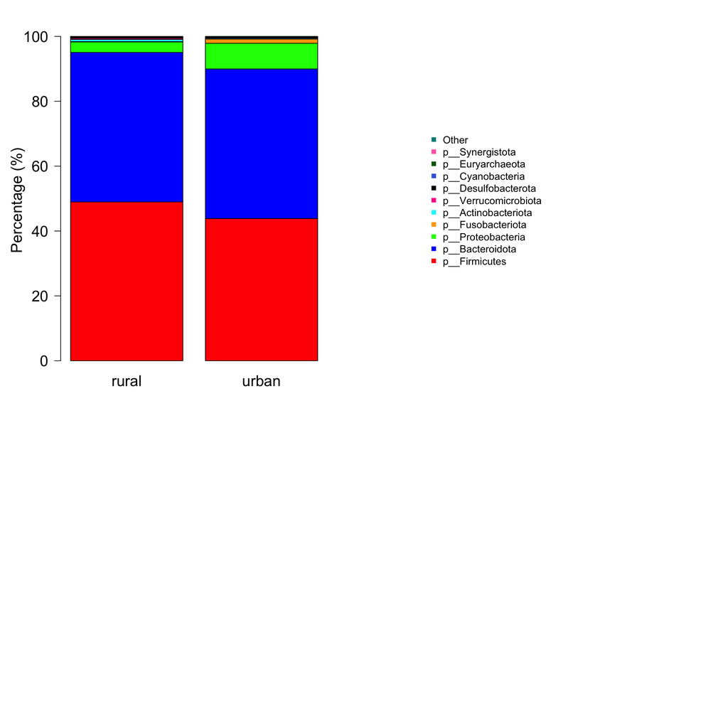

### Barplot at genus level

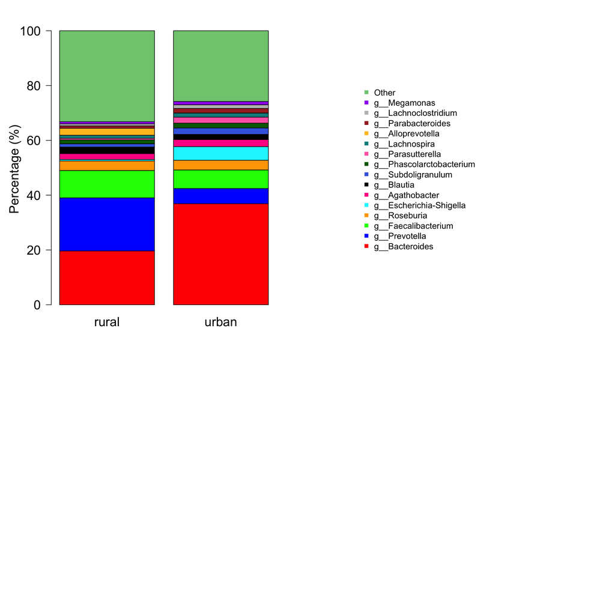